# 체중보정 허리둘레지수(WWI)와 뇌졸중 — 논문 한 편을 처음부터 끝까지 따라가기

Ye J, et al. *Association between the weight-adjusted waist index and stroke: a cross-sectional study.* BMC Public Health 2023;23:1689 (PMID 37658310) · 2주차 과제 해설 · NHANES 2011–2020 실제 자료로 재현한 숫자 포함

이 문서와 「논문을 읽기 위한 통계 최단학습경로」PDF의 역할 분담

통계 **기법 자체의 수식과 원리**(왜도, Q–Q plot, Shapiro–Wilk, Levene, 로그변환, 복합표본 가중치, 카이제곱, 오즈비, 로지스틱 회귀 등)는 이미 PDF에 정리되어 있으므로 여기서 다시 쓰지 않습니다. 이 문서는 **그 기법들이 이 논문 안에서 "어떤 순서로, 왜" 쓰였는가**를 따라갑니다. 수식이 필요한 자리마다 PDF §2.2 같은 표식으로 해당 절을 가리킵니다. 이 문서에만 있는 내용은 ⑥ 상호작용 p값, ④의 "이 논문 전용" 전처리 판단, ⑨ 실제 재현 결과입니다.

## ① 문제의 정의 — 이 연구는 왜 시작되었나

### 배경: 두 가지 큰 문제가 만나는 지점

**뇌졸중**은 뇌혈관이 막히거나 터져서 생기는 병으로, 전 세계 사망 원인 2위입니다. 1990년에서 2019년 사이 발생이 70% 늘었고, 연간 비용은 890억 달러가 넘습니다. 그래서 "미리 막을 수 있는 위험 요인"을 찾는 것이 중요합니다.

**비만**은 잘 알려진 뇌졸중 위험 요인입니다. 그런데 비만을 재는 자(尺)에 문제가 있습니다.

기존 지표의 한계

**BMI** \( = \dfrac{\text{체중(kg)}}{\text{키(m)}^2} \) — 근육이 많은 운동선수도 "비만"으로 나옵니다. 지방과 근육을 구별하지 못합니다.

**허리둘레(WC)** — 뱃살(중심성 비만)을 잘 반영하지만, 덩치가 큰 사람은 지방이 적어도 허리둘레가 큽니다. 체중과 너무 강하게 묶여 있습니다.

새 지표: 체중보정 허리둘레지수 (WWI)

$$\mathrm{WWI}\;(\text{cm}/\sqrt{\text{kg}}) = \frac{\text{허리둘레 (cm)}}{\sqrt{\text{체중 (kg)}}}$$

허리둘레를 체중의 제곱근으로 나눕니다. 같은 허리둘레라도 체중이 무거우면 WWI는 작아집니다. 즉 **"몸무게에 비해 허리가 얼마나 굵은가"**를 재는 것이라, 지방이 뱃속에 몰려 있는 정도를 체중과 떼어 놓고 볼 수 있습니다.

왜 제곱근일까? (고등학생용 직관)

체중은 부피에 비례하고, 부피는 길이의 세제곱입니다(\(V \propto L^3\)). 허리둘레는 길이(\(L^1\))입니다. 그냥 나누면(\(\mathrm{WC}/\text{체중}\)) 단위가 \(L^{-2}\)이 되어 큰 사람일수록 무조건 작아집니다. 제곱근을 씌우면 \(L^{1.5}\)가 되어 "키·덩치가 커질 때 허리도 자연스럽게 커지는 만큼"을 대략 상쇄하고, 남는 것은 **덩치와 무관한 뱃살 정도**가 됩니다. 원 개발자(Park 2018)가 여러 지수 중 사망·심혈관질환을 가장 잘 예측하는 형태로 경험적으로 고른 것이기도 합니다.

### 문제의 정의 (연구 질문)

이 논문이 던진 질문

"WWI가 높은 사람은 뇌졸중을 앓았을 가능성도 높은가? 만약 그렇다면, 나이·성별·당뇨·고혈압 같은 다른 요인들을 감안하고도 그 관계가 남아 있는가?"

이전 연구들은 WWI가 복부대동맥 석회화, 골다공증, 심부전과 관련 있음을 보였지만, **뇌졸중과의 관계는 아무도 조사하지 않았습니다.** 그 빈칸을 채우는 것이 이 연구의 출발점입니다.

## ② 무엇과 무엇의 관계를 알아냈나 — 노출, 결과, 그리고 방해꾼

역학 논문은 항상 세 종류의 변수로 이루어집니다. 이 논문에서는 다음과 같습니다.

| 역할 | 이 논문에서 | 어떻게 쟀나 | NHANES 변수명 |
| --- | --- | --- | --- |
| **노출 (X)** 원인 쪽 후보 | WWI (연속형, 그리고 4분위군) | 이동검진센터에서 전문가가 디지털 체중계와 줄자로 직접 측정. 자기보고가 아님 → 측정 오차가 작음 | `BMXWAIST` / √`BMXWT` |
| **결과 (Y)** 알고 싶은 병 | 뇌졸중 (있음/없음) | 설문: "의사에게 뇌졸중이 있다고 들은 적이 있습니까?" 에 "예" → 1. **자기보고**이며 뇌졸중 종류(허혈/출혈)는 모름 | `MCQ160F` |
| **공변량 (Z)** 방해꾼 = 교란변수 후보 | 나이, 성별, 인종, 교육, 흡연, 음주, 당뇨, 고혈압, 관상동맥질환, 암, 소득(PIR), 중성지방, 총콜레스테롤, HDL-C, LDL-C | 설문 + 혈액검사. WWI와 뇌졸중 **둘 다에** 영향을 줄 수 있어서 관계를 왜곡할 수 있는 변수들 | `RIDAGEYR`, `RIAGENDR`, `RIDRETH3`, `DMDEDUC2`, `SMQ020`, `ALQ130`, `DIQ010`, `BPQ020`, `MCQ160C`, `MCQ220`, `INDFMPIR`, `LBXTR`, `LBXTC`, `LBDHDD`, `LBDLDL` |

"관계"이지 "원인"이 아니다 — 단면연구의 한계

이 연구는 **단면연구(cross-sectional)**입니다. 한 시점에 WWI와 뇌졸중 여부를 *동시에* 잰 것이라, 무엇이 먼저인지 모릅니다. 뇌졸중을 앓은 뒤 활동량이 줄어 뱃살이 늘었을 수도 있습니다(역인과). 그래서 논문도 "association(연관)"이라고만 쓰고 "causes(일으킨다)"라고 쓰지 않습니다. 결론 문장 "높은 WWI는 뇌졸중 **유병률**(prevalence)과 연관되었다"에서 '유병률'은 "이미 앓고 있는 비율"이라는 뜻으로, 새로 생길 위험(incidence)이 아닙니다.

### 교란변수를 고등학생 눈높이로

아이스크림 판매량과 익사 사고 수는 같이 늘어납니다. 아이스크림이 익사를 일으킬까요? 아닙니다. **여름(기온)**이 둘 다를 늘립니다. 기온이 **교란변수**입니다. 이 논문에서는 **나이**가 대표적인 교란변수입니다: 나이가 들면 WWI도 커지고(근육↓ 뱃살↑) 뇌졸중도 늘어납니다. 나이를 감안하지 않으면 WWI와 뇌졸중이 실제보다 훨씬 강하게 묶여 보입니다. 실제로 논문 Table 2에서 아무것도 보정하지 않은 OR은 1.94였다가 나이·성별·인종을 보정하니 1.36으로 뚝 떨어집니다. 그 차이가 바로 교란의 크기입니다. PDF §11.1 교란이란 무엇인가

## ③ 자료 — NHANES는 어떤 자료이고 어떻게 23,389명이 되었나

### NHANES란

미국 CDC가 2년 주기로 시행하는 국민건강영양조사입니다. 가정 방문 설문 + 이동검진센터(MEC) 신체계측·혈액검사로 이루어지며 **누구나 신청 없이 내려받을 수 있습니다.** 이 논문은 "2011–2020"이라고 썼는데, 실제로는 다음 4개 파일입니다. 초기 인원 45,462명이 이 합계와 **정확히** 맞는 것으로 확인했습니다.

| 주기 | nhanesA 표 이름 규칙 | DEMO 인원 | 비고 |
| --- | --- | --- | --- |
| 2011–2012 | `DEMO_G`, `BMX_G`, … | 9,756 |  |
| 2013–2014 | `DEMO_H`, … | 10,175 |  |
| 2015–2016 | `DEMO_I`, … | 9,971 |  |
| 2017–2020.3 (팬데믹 전) | `P_DEMO`, `P_BMX`, … (접두사) | 15,560 | 2017–2018(J) 파일과 다름. 3.2년치가 합쳐진 특수 파일 |
| 합계 |  | 45,462 | = 논문 Fig.1 초기 인원 ✔ |

NHANES의 결정적 특징: 단순 임의추출이 아니다

미국 전체에서 무작위로 사람을 뽑은 것이 아니라, 고령자·흑인·히스패닉·저소득층 등을 **일부러 더 많이** 뽑았습니다(그래야 그 집단의 통계도 정밀해지니까). 그래서 표본 그대로 평균을 내면 미국 국민의 평균이 아닙니다. 이를 되돌리는 것이 **표본 가중치**이고, 같은 동네 사람끼리 비슷한 것(군집)까지 반영해야 표준오차가 맞습니다. PDF §2.7 복합표본 가중치 이 문서 ⑨에서 이 가중치를 논문이 어디에 썼고 어디에 안 썼는지 실제로 확인합니다.

### Fig. 1 — 제외 단계 재현

논문은 45,462명에서 시작해 세 단계로 사람을 제외합니다. 우리가 내려받은 자료로 **똑같은 순서**로 제외했을 때의 인원입니다.

| 단계 | 논문 (Fig.1) | 재현 | 일치 | 비고 |
| --- | --- | --- | --- | --- |
| NHANES 2011–2020 초기 인원 | 45,462 | 45,462 | ✔ | 4개 주기 DEMO 합 |
| 체중(`BMXWT`) 결측 제외 (−2,976) | 42,486 | 42,486 | ✔ | 검진센터에 안 온 사람 등 |
| 허리둘레(`BMXWAIST`) 결측 제외 (−4,767) | 37,719 | 37,719 | ✔ | 2세 미만은 허리둘레를 재지 않음 |
| 뇌졸중(`MCQ160F`) 결측 제외 (−14,330) | 23,389 | 23,389 | ✔ | 이 질문은 **20세 이상**에게만 하므로 결측 14,330명 중 14,329명이 20세 미만. "모름"이라고 답한 22명은 논문이 제외하지 않았음(뇌졸중 없음으로 처리) |

"모름(코드 9) 22명" 처리는 논문에 명시되어 있지 않지만, 23,389 = 예 893 + 아니오 22,474 + 모름 22 로 정확히 맞아떨어지므로 논문이 이들을 포함했다는 것을 역산할 수 있습니다. 재현할 때 이런 작은 규칙 하나가 n을 바꿉니다.

## ④ 전처리 — 분석 전에 무엇을 했고, 왜도에 따라 왜 다른 자료를 쓰는가

"전처리"는 원자료를 분석 가능한 형태로 다듬는 모든 작업입니다. 이 논문(그리고 재현)에서 실제로 필요한 단계를 순서대로 정리합니다.

### 4-1. 표 결합과 결측 제외

NHANES는 설문·계측·혈액이 각각 다른 파일이므로 사람 번호 `SEQN`으로 이어 붙입니다. 그다음 위의 Fig.1 순서대로 제외합니다. (R: `dplyr::left_join`)

### 4-2. WWI 계산과 사분위(quartile) 절단

\(\mathrm{WWI} = \mathrm{BMXWAIST}/\sqrt{\mathrm{BMXWT}}\) 를 계산한 뒤, 값을 크기순으로 나열해 25%, 50%, 75% 지점에서 잘라 네 그룹(Q1~Q4)으로 나눕니다. 재현한 절단점은 **10.51 / 11.09 / 11.67**로 논문과 소수 둘째 자리까지 일치했습니다.

왜 연속형과 4분위군을 둘 다 쓰나

- **연속형**: "WWI 1단위 오를 때마다"라는 한 개의 숫자(OR)로 요약. 간결하지만 관계가 직선이라고 가정함.
- **4분위군**: 직선 가정 없이 "가장 낮은 그룹 대비 가장 높은 그룹"을 비교. 곡선 관계도 잡아내고 일반인이 이해하기 쉬움. 대신 정보를 버림. PDF §10.6 범주화 vs 스플라인

### 4-3. 코드값(특수값) 정리

NHANES 설문은 "거부"를 777, "모름"을 999 같은 숫자로 저장합니다. 이걸 그대로 두고 평균을 내면 하루 음주량에 "999잔"이 섞입니다. 반드시 결측(NA)으로 바꿔야 합니다. 재현 코드는 `alcohol = ifelse(ALQ130 %in% c(777, 999), NA, ALQ130)`으로 처리했습니다.

| Q1 음주량 (가중 mean ± SD) | Q1 | Q2 | Q3 | Q4 |
| --- | --- | --- | --- | --- |
| 777/999를 그대로 둔 경우 | 3.32 ± 20.79 | 4.47 ± 42.31 | 3.06 ± 22.29 | 3.42 ± 31.09 |
| **논문 Table 1** | 3.24 ± 18.67 | 4.29 ± 39.96 | 2.99 ± 20.49 | 3.33 ± 29.64 |
| 777/999 → NA (재현 코드) | 2.89 ± 2.50 | 2.68 ± 2.34 | 2.54 ± 2.14 | 2.29 ± 2.15 |

논문은 코드값을 정리하지 않았다

논문의 값은 "777/999를 그대로 둔" 행과 같은 패턴입니다(Q2에서 SD가 40 근처로 튀는 것까지). 응답자 15,032명 중 777·999로 기록된 사람은 18명뿐이지만, 이들이 "하루 999잔"으로 계산되어 SD를 2.5에서 20~40으로 부풀렸습니다. 이 변수만 유일하게 P=0.187로 유의하지 않은 것도 이 때문입니다(정리 후에는 P<0.001). 재현값이 논문과 **일부러 다른** 유일한 항목이며, "SD가 평균의 6배"인 행을 보면 코드값 오염을 의심하라는 교훈입니다.

### 4-4. 가중치 재조정 — 4개 주기를 합칠 때

각 주기의 가중치 `WTMEC2YR`는 "그 2년 동안의 미국 인구"를 대표하도록 만들어져 있습니다. 4개 주기(총 9.2년)를 합치면 미국 인구를 4번 세는 셈이므로 **기간 비율만큼 나눠 줘야** 합니다. CDC 지침:

$$w_i^{\text{new}} = \begin{cases} \dfrac{2}{9.2}\times \mathrm{WTMEC2YR}_i & (2011\text{–}2016 \text{ 각 주기}) \\[8pt] \dfrac{3.2}{9.2}\times \mathrm{WTMECPRP}_i & (2017\text{–}2020.3) \end{cases}$$

재현으로 확인된 사실: 논문은 "설문 가중치"를 재조정 없이 그대로 썼다

그리고 층(`SDMVSTRA`)과 군집(`SDMVPSU`)을 함께 지정해야 표준오차가 맞습니다. R에서는 `survey::svydesign(id=~SDMVPSU, strata=~SDMVSTRA, weights=~w, nest=TRUE)` 한 줄입니다.

### 4-5. 분포 진단 — 왜도에 따라 "쓰는 자료"가 달라지는 이유

핵심 질문: 왜 어떤 변수는 그대로 쓰고, 어떤 변수는 로그를 씌우거나 중앙값으로 보고하나?

평균과 표준편차, t검정, 선형회귀는 모두 자료가 **좌우 대칭(정규분포에 가까움)**일 때 제 역할을 합니다. 자료가 한쪽으로 길게 늘어져 있으면(**왜도** \(g_1\)이 큼) 평균은 소수의 극단값에 끌려가서 "보통 사람"을 대표하지 못하고, 표준편차는 의미를 잃고, 검정의 p값도 믿을 수 없게 됩니다. 그래서 분석 *전에* 변수마다 분포를 진단하고, 치우친 변수는 (a) 로그변환해서 대칭으로 만들거나 (b) 중앙값(IQR)으로 보고하거나 (c) 비모수 검정을 씁니다. PDF §2.2 왜도 §2.3 Q–Q plot §2.4 Shapiro–Wilk §2.6 로그변환

23,389명 자료로 논문 Table 1의 연속변수를 실제로 진단한 결과입니다. (Shapiro–Wilk는 R 내장함수 한계 n ≤ 5,000 때문에 무작위 5,000명 표본으로 계산)

| 변수 | 평균 | 중앙값 | 왜도 (원자료) | S–W W (원) | 왜도 (로그) | S–W W (로그) | 판정 |
| --- | --- | --- | --- | --- | --- | --- | --- |
| 중성지방 `LBXTR` | 117.3 | 94 | 11.42 | 0.574 | 0.38 | 0.993 | **극심한 우측 치우침 → 로그변환 필수.** 평균이 중앙값보다 25% 큼 |
| 음주량 `ALQ130` | 2.66 | 2 | 5.00 | 0.597 | 0.64 | 0.877 | 우측 치우침 → 로그변환으로 크게 개선(완전하진 않음: 정수값이라 계단 모양) |
| BMI `BMXBMI` | 29.4 | 28.2 | 1.16 | 0.935 | 0.36 | 0.993 | 중간 정도 치우침 → 로그로 개선 |
| 체중 `BMXWT` | 82.0 | 78.8 | 1.01 | 0.950 | 0.18 | 0.998 | 중간 치우침 → 로그로 개선 |
| HDL-C `LBDHDD` | 53.3 | 51 | 1.20 | 0.927 | 0.04 | 0.997 | 로그 후 거의 완벽한 대칭 |
| **WWI** | 11.09 | 11.09 | 0.02 | 0.999 | −0.19 | 0.998 | **이미 대칭. 로그 불필요.** 평균 = 중앙값 |
| 나이 `RIDAGEYR` | 49.3 | 49 | 0.08 | 0.961 | −0.44 | 0.947 | 대칭이지만 납작함(첨도 −1.1). **로그를 씌우면 오히려 나빠짐** |
| 소득비 `INDFMPIR` | 2.52 | 2.11 | 0.34 | 0.899 | −1.29 | 0.885 | 0값 171명 + 5에서 잘린 값 → **로그가 해답이 아님**. 그대로 두거나 범주화 |

이 표에서 읽어야 할 세 가지

1. **같은 논문 안에서도 변수마다 처방이 다릅니다.** 중성지방은 로그가 필수이고, WWI는 손댈 필요가 없고, 나이와 PIR은 로그를 씌우면 오히려 망가집니다. "치우침이 있으면 로그"가 아니라, **"곱셈적으로 자라는 양(농도·비용)이 오른쪽으로 치우쳤을 때"** 로그가 맞는 처방입니다.
2. **Shapiro–Wilk p값은 전부 <0.001입니다**(표에는 W만 실었습니다). n이 수천이면 미세한 비정규성도 유의해지므로 p로는 아무것도 구별할 수 없습니다. 대신 **W 값의 크기**(1에 가까울수록 정규)와 **왜도**, 그리고 **그림**으로 판단합니다. PDF §2.4 흔한 오해
3. 논문 Table 1은 **모든 연속변수를 mean ± SD로 보고**했습니다. 중성지방(왜도 11)과 음주량(SD가 평균의 6배)은 이 형식이 부적절합니다. 이 과제에서 "로그변환의 근거"를 요구하는 이유가 바로 이것입니다 — 저자보다 한 단계 더 엄밀하게 진단하라는 뜻입니다.

### 4-6. 그림으로 확인 — 히스토그램과 Q–Q plot (원자료 vs 로그변환)

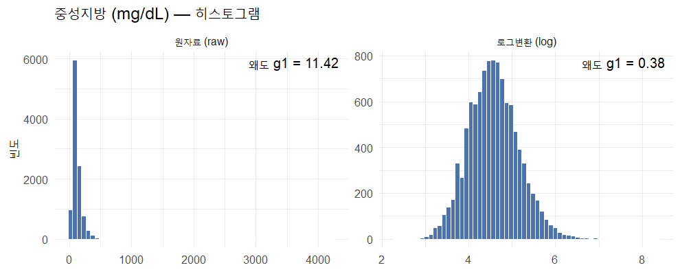

**중성지방.** 왼쪽(원자료)은 0 근처에 몰려 있고 오른쪽으로 4,000까지 꼬리가 늘어져 왜도 11.4. 오른쪽(로그)은 종 모양으로 왜도 0.38. 같은 자료를 자(尺)만 바꿔 본 것입니다.

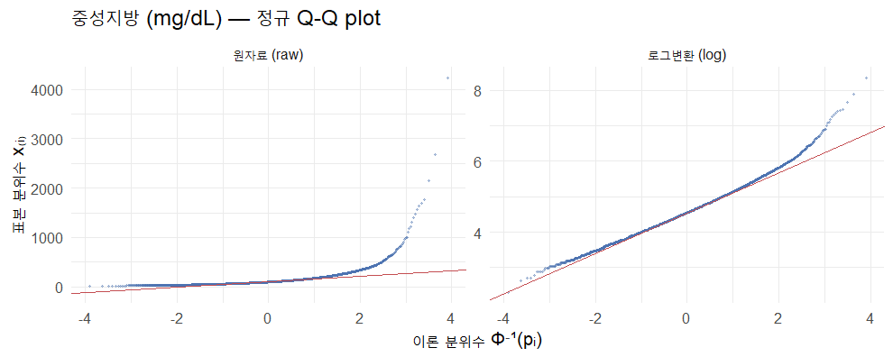

**중성지방 Q–Q plot.** 점이 빨간 직선 위에 있으면 정규분포. 원자료는 오른쪽 끝이 위로 솟구침(= 오른쪽 꼬리가 정규보다 훨씬 무거움). 로그변환 후 거의 직선. x축은 \(\Phi^{-1}(p_i)\), y축은 정렬한 표본값 \(x_{(i)}\). PDF §2.3

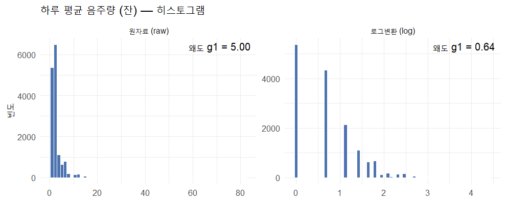

**하루 평균 음주량.** 정수(1잔, 2잔, …)라서 막대가 듬성듬성하고, 로그 후에도 완전한 종 모양은 아닙니다. 로그가 "만능"이 아니라는 예. 이런 변수는 범주화(비음주/적정/과음)가 더 흔한 선택입니다.

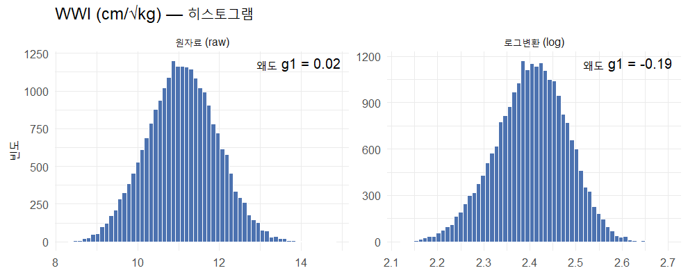

**WWI.** 이미 대칭(왜도 0.02)이므로 노출변수는 원자료 그대로 씁니다. 로그를 씌우면 약간 왼쪽으로 기울어 오히려 손해.

### 4-7. 등분산 — Levene 검정은 어디에 쓰였나

Table 1의 P값은 "네 그룹의 평균이 같은가"를 묻는 것이고, 이런 비교(t검정·ANOVA)는 **그룹마다 퍼짐(분산)이 비슷하다**고 가정합니다. Levene 검정으로 확인한 결과입니다. PDF §2.5

| 변수 (WWI 4분위군 간) | Levene p (원자료) | Levene p (로그) | 해석 |
| --- | --- | --- | --- |
| 중성지방 | 3.9 × 10⁻¹⁰ | 4.3 × 10⁻⁶ | 로그 후에도 등분산 기각 → Welch형 검정 또는 가중회귀(로버스트 SE) |
| 음주량 | 7.9 × 10⁻⁴ | 0.97 | **로그 후 등분산 만족** — 로그변환의 두 번째 근거(등분산화)의 실례 |
| BMI | ≈ 0 | ≈ 0 | WWI가 높을수록 BMI 퍼짐도 커짐. 로그로 완화되나 해소 안 됨 |

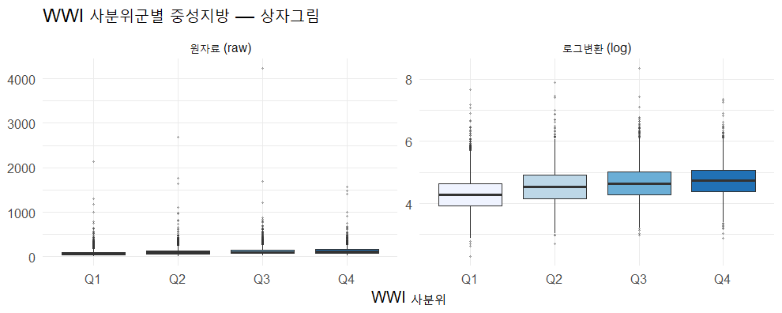

**상자그림.** 원자료(왼쪽)는 상자가 바닥에 눌리고 이상치가 위로 흩뿌려져 그룹 간 비교가 불가능. 로그(오른쪽)는 상자 크기가 비슷해지고 Q1→Q4로 갈수록 중앙값이 올라가는 경향이 보임.

실무 참고: 논문은 Table 1의 P를 "가중 선형회귀"로 계산했습니다. `survey` 패키지의 `svyglm`은 설계 기반(로버스트) 표준오차를 쓰므로 등분산 가정에 상대적으로 덜 민감합니다. 그래도 극심하게 치우친 변수는 로그 후에 넣는 것이 정석입니다.

## ⑤ 분석 방법 — 관계를 알아내기 위해 어떤 순서로 무엇을 했나

논문의 통계 분석은 다섯 단계입니다. 각 단계는 "앞 단계에서 생긴 의문"에 답하기 위해 존재합니다.

**1단계 · Table 1 — 네 그룹은 어떻게 다른가?**  
WWI 4분위군별로 나이·성별·질병·혈액 수치를 나열. 연속변수는 가중 평균±SD와 **가중 선형회귀**의 P, 범주변수는 가중 %와 **가중 카이제곱(Rao–Scott)**의 P. PDF §5.2, §5.6  
→ 결과: Q4는 Q1보다 나이가 20살 많고, 당뇨 9배, 고혈압 4배. 즉 **WWI 높은 그룹은 다른 위험요인도 다 많다**. 여기서 "그럼 뇌졸중이 많은 게 WWI 때문인지 나이·당뇨 때문인지 어떻게 아나?"라는 의문이 생김 → 2단계.

↓

**2단계 · Table 2 — 다변량 로지스틱 회귀 (모형 3개)**  
뇌졸중(0/1)을 결과로 놓고 WWI의 효과를 **오즈비(OR)**로 추정. 교란변수를 단계적으로 추가:  
Model 1 = 보정 없음 · Model 2 = + 나이·성별·인종 · Model 3 = + 교육·음주·흡연·당뇨·고혈압·관상동맥질환·암·PIR·혈액 4종. PDF §7.1  
→ 결과: OR 1.94 → 1.36 → 1.25. 보정할수록 줄지만 **1을 넘는 채로 유의하게 남음**. "다른 요인을 다 감안해도 WWI 자체의 몫이 있다"는 뜻.

↓

**3단계 · Table 2 아래쪽 — 4분위군 OR과 P for trend**  
Q1을 기준(OR=1)으로 Q2, Q3, Q4의 OR을 구하고, Q1→Q4로 갈수록 OR이 **단조롭게 증가하는지** 경향성 검정. PDF §4.3  
→ Model 3에서 Q4 OR 1.62 (1.06–2.48), P for trend 0.038. "높을수록 더 위험"이 계단식으로 확인됨.

↓

**4단계 · Fig. 2 — 평활곡선(smoothing curve)**  
WWI를 그룹으로 자르지 않고, 연속값 그대로 뇌졸중 확률과의 관계를 부드러운 곡선으로 그림(일반화가법모형). 직선인지 곡선인지, 어디서 꺾이는지 확인. PDF §10.6 스플라인  
→ 비선형이지만 전체적으로 오른쪽 위로 향하는 양의 관계.

↓

**5단계 · Table 3 — 하위군 분석과 상호작용 검정**  
성별·나이·인종·교육·당뇨·고혈압·관상동맥질환·암으로 사람을 나눠 **각 그룹 안에서 따로** OR을 구하고, 그룹 간 OR이 통계적으로 다른지 **상호작용 p값**으로 검정.  
→ 모든 상호작용 p > 0.05. "이 관계는 특정 집단에서만 나타나는 게 아니다" → ⑥에서 자세히.

### Table 2의 수식 — 논문이 실제로 돌린 모형

Model 3를 식으로 쓰면 다음과 같습니다. (\(p\) = 뇌졸중 확률, \(Z_1,\dots,Z_{15}\) = 공변량 15개)

$$\log\frac{p}{1-p} \;=\; \beta_0 \;+\; \underbrace{\beta_1\,\mathrm{WWI}}_{\text{알고 싶은 것}} \;+\; \underbrace{\gamma_1 Z_1 + \gamma_2 Z_2 + \cdots + \gamma_{15} Z_{15}}_{\text{교란변수 보정}}$$ $$\mathrm{OR}_{\text{WWI 1단위}} = e^{\beta_1} = 1.25 \quad(\text{95\% CI } 1.05\text{–}1.48)$$

"\(\beta_1\)"은 **공변량들을 모두 고정한 채** WWI가 1 오를 때 로그오즈가 얼마나 오르는가입니다. 그래서 \(e^{\beta_1}\)을 "보정된 OR"이라 부릅니다. 로지스틱 회귀가 무엇이고 왜 로짓을 쓰는지는 PDF §7.1에 있습니다.

### 4분위군 모형과 P for trend

$$\log\frac{p}{1-p} = \beta_0 + \beta_2\,[Q2] + \beta_3\,[Q3] + \beta_4\,[Q4] + \gamma^\top Z, \qquad [Qk]=\begin{cases}1 & \text{그 사람이 }Qk\\0 & \text{아니면}\end{cases}$$

Q1이 기준이라 항이 없고(OR = 1), \(e^{\beta_4} = 1.62\)가 "Q4는 Q1보다 62% 높다"입니다. **P for trend**는 Q1~Q4에 1, 2, 3, 4를 넣어 *하나의 연속변수처럼* 돌렸을 때 그 계수가 0인지 검정한 것입니다 — "그룹이 올라갈수록 위험이 *순서대로* 커지는가"를 자유도 1로 묻기 때문에 그냥 "네 그룹이 다른가"보다 검정력이 높습니다. PDF §4.3

## ⑥ "인구 집단이 달라도 관계가 비슷했다" — 상호작용 p값의 정확한 뜻

먼저 결론

Table 3의 "P for interaction > 0.05"는 **"WWI가 뇌졸중에 미치는 효과의 크기가 남녀(또는 나이·인종 등)에 따라 다르다는 통계적 증거를 찾지 못했다"**는 뜻입니다. "남녀에서 똑같다"는 증명이 *아니고*, "다르다고 말할 근거가 없다"입니다. 이 차이가 이 절의 전부입니다.

### 6-1. 상호작용(interaction)이란 무엇인가

약 A가 젊은 사람에게는 혈압을 20 낮추고, 노인에게는 5만 낮춘다면 "약 효과가 나이와 **상호작용**한다"고 합니다. 효과의 *크기*가 다른 변수의 값에 따라 달라지는 것입니다. 이 논문의 질문은: "WWI 1단위당 뇌졸중 오즈가 오르는 정도(OR)가 남성과 여성에서 다른가?"

### 6-2. 수식 — 곱셈항 하나를 넣는 것이 전부

성별을 \(G\) (남=0, 여=1)라 하고, 기존 모형에 **WWI × G** 항을 추가합니다.

$$\log\frac{p}{1-p} = \beta_0 + \beta_1\,\mathrm{WWI} + \beta_2\,G + \underbrace{\beta_3\,(\mathrm{WWI}\times G)}_{\text{상호작용항}} + \gamma^\top Z$$

이 식을 남녀로 따로 풀어 보면 왜 \(\beta_3\)가 "차이"인지 보입니다.

$$\text{남성 }(G=0):\quad \log\frac{p}{1-p} = \beta_0 + \beta_1\,\mathrm{WWI} + \gamma^\top Z \qquad\Rightarrow\; \mathrm{OR}_{\text{남}} = e^{\beta_1}$$ $$\text{여성 }(G=1):\quad \log\frac{p}{1-p} = (\beta_0+\beta_2) + (\beta_1+\beta_3)\,\mathrm{WWI} + \gamma^\top Z \qquad\Rightarrow\; \mathrm{OR}_{\text{여}} = e^{\beta_1+\beta_3}$$ $$\frac{\mathrm{OR}_{\text{여}}}{\mathrm{OR}_{\text{남}}} = e^{\beta_3}$$

즉 \(\beta_3\)는 **"여성의 WWI 기울기 − 남성의 WWI 기울기"**이고, \(e^{\beta_3}\)는 두 OR의 **비율**입니다.

상호작용 검정의 가설

$$H_0:\ \beta_3 = 0 \;\;(\text{즉 } \mathrm{OR}_{\text{남}} = \mathrm{OR}_{\text{여}}) \qquad H_1:\ \beta_3 \neq 0$$

검정통계량은 다른 계수와 똑같이 Wald \(z = \hat\beta_3 / \mathrm{SE}(\hat\beta_3)\) 또는 상호작용항이 있는 모형과 없는 모형의 우도비 검정(LRT)입니다. PDF §7.2 나온 p가 "P for interaction"입니다. 그룹이 3개 이상(인종 4군)이면 상호작용항이 3개이므로 자유도 3의 LRT를 씁니다.

### 6-3. 이 논문의 Table 3 읽기

| 하위군 | OR (95% CI) | P for interaction | 읽는 법 |  |  |
| --- | --- | --- | --- | --- | --- |
| 남성 | 1.39 (1.11–1.74) | 0.103 | 남성 OR이 더 커 보이지만, 두 CI가 크게 겹치고 p=0.10 → 우연으로 설명 가능한 차이. "남녀 모두에서 같은 방향" |  |  |
| 여성 | 1.11 (0.90–1.38) |  |  |  |  |
| <60세 | 1.72 (1.39–2.13) |  |  | 0.131 | 젊은 층에서 OR이 크지만 역시 유의한 차이 아님 |
| ≥60세 | 1.41 (1.15–1.73) |  |  |  |  |
| 당뇨 있음 | 1.42 (1.06–1.91) | >0.05 | 당뇨 유무와 무관하게 양의 관계 |  |  |
| 당뇨 없음 | 1.19 (0.97–1.45) |  |  |  |  |

함정 1: 하위군 하나의 CI가 1을 포함한다고 "그 그룹에선 효과가 없다"가 아니다

여성 OR 1.11 (0.90–1.38)은 1을 포함하니 "여성에서는 유의하지 않다"고 쓰고 싶어집니다. 그러나 올바른 비교는 **여성 vs 남성의 차이**(상호작용 p=0.10)이지, 각 그룹의 유의성을 따로 보는 것이 아닙니다. 그룹을 반으로 나누면 표본이 반으로 줄어 CI가 넓어지는 것은 당연합니다. "한쪽은 유의, 다른 쪽은 비유의 → 차이가 있다"는 가장 흔한 오독입니다.

함정 2: p > 0.05 는 "같다"의 증명이 아니다 — 검정력 문제

상호작용 검정은 원래 검정력이 낮습니다. 뇌졸중이 893명뿐인데 이를 다시 남녀로 쪼개면 각 그룹의 정보가 줄고, 상호작용항의 표준오차는 주효과의 2배 이상으로 커집니다. 그래서 실제로 OR이 1.4 vs 1.1로 다르더라도 p < 0.05를 얻지 못하는 일이 흔합니다. 논문이 "similar(비슷했다)"라고 쓴 것은 관행적 표현이며, 정확히는 **"이질성(heterogeneity)을 검출하지 못했다"**입니다.

함정 3: 8번 검정하면 우연히 하나는 유의해진다

Table 3는 8개 변수로 상호작용을 검정했습니다. 모두 진짜로 상호작용이 없더라도, 5% 유의수준에서 8번 중 적어도 하나가 유의할 확률은 \(1-0.95^8 \approx 34\%\)입니다. 이번엔 모두 p>0.05였으니 문제가 되진 않았지만, 만약 하나가 0.03이 나왔다면 "발견"이 아니라 우연을 먼저 의심해야 합니다. PDF §4.4 다중비교

### 6-4. 그러면 이 검정을 왜 하는가

두 가지 목적이 있습니다.

1. **강건성(robustness) 확인**: 전체 결과(OR 1.25)가 어떤 특정 집단 하나가 끌고 간 것이 아님을 보여줍니다. 남성에서도, 여성에서도, 젊어도, 늙어도 방향이 같으면 결과를 더 믿을 수 있습니다.
2. **효과변경인자(effect modifier) 탐색**: 만약 당뇨 환자에서만 OR이 3이고 비당뇨에서 1이라면 "WWI는 당뇨 환자에서 특히 중요"라는 새 가설이 생깁니다. 이번 논문에서는 그런 집단이 발견되지 않았습니다.

이것이 논문 초록의 마지막 문장 "this positive correlation was similar in different population settings (all P for interaction >0.05)"의 정확한 의미입니다.

실제 자료로 해 본 상호작용 검정 (Model 2 수준, 성별)

재현 자료 23,389명으로 WWI × 성별 상호작용을 검정하면 LRT p = **0.20**, 남성 OR 1.45, 여성 OR 1.29 (Model 2 보정, 비가중). 논문(p = 0.103, 1.39 vs 1.11)과 같은 결론입니다. R 코드는 단 두 줄입니다:

```
m0 <- glm(stroke ~ WWI + sex + RIDAGEYR + race, dat, family = binomial())
m1 <- glm(stroke ~ WWI * sex + RIDAGEYR + race, dat, family = binomial())   # WWI*sex = WWI + sex + WWI:sex
anova(m0, m1, test = "LRT")          # P for interaction
```

## ⑦ 결과 읽기 — OR 1.25, 62%, 괄호 안 숫자의 의미

### 오즈(odds)와 오즈비(OR)를 한 번만 제대로

확률 \(p = 0.04\)(뇌졸중 4%)이면 오즈는 \(p/(1-p) = 0.04/0.96 \approx 0.042\), 즉 "안 걸린 사람 24명당 걸린 사람 1명"입니다. OR 1.25는 **WWI가 1 높은 사람의 오즈가 1.25배**라는 뜻입니다. 뇌졸중처럼 드문 병(<10%)에서는 오즈비 ≈ 확률비이므로 "약 25% 더 흔하다"로 읽어도 큰 오차가 없습니다. PDF §5.3 오즈비와 상대위험

| 논문 표현 | 정확한 번역 |
| --- | --- |
| OR 1.25 (1.05, 1.48) | WWI 1단위(≈ 표준편차 0.86의 1.2배) 높을수록 뇌졸중 오즈 25%↑. 참값이 5%↑~48%↑ 사이일 것으로 95% 확신. 구간이 1을 포함하지 않으므로 p < 0.05 |
| Q4 vs Q1: 1.62 (1.06, 2.48) | WWI 상위 25%는 하위 25%보다 뇌졸중 오즈 62%↑. 하한 1.06이 1에 가까워 "겨우 유의" |
| P for trend = 0.038 | Q1→Q4로 갈수록 오즈가 순서대로 커지는 경향이 우연이 아닐 가능성이 큼(하지만 0.05에 가까움) |
| Model 1 → 3에서 OR 1.94 → 1.25 | 보정 전 효과의 대부분은 나이 등 교란변수 때문이었고, 순수하게 WWI 몫으로 남은 것이 1.25 |

WWI 1단위는 실생활에서 얼마인가

체중 80 kg인 사람은 \(\sqrt{80} \approx 8.94\)이므로 WWI 1단위 = 허리둘레 약 **8.9 cm**입니다. "몸무게는 그대로인데 허리가 9 cm 굵어지면 뇌졸중 오즈가 25% 오른다"가 이 논문의 핵심 숫자입니다. 전체 표본의 WWI 표준편차가 0.86이니, 1단위는 꽤 큰 변화입니다.

### 이 논문의 한계 — 저자 스스로 밝힌 것

- 단면연구 → 인과 불가 (역인과 가능)
- 뇌졸중이 자기보고 → 오분류 가능, 허혈/출혈 구분 없음
- 평균 나이 49세 → 뇌졸중 발생이 원래 낮은 연령대
- 측정 안 된 교란변수(신체활동, 식이 등)는 보정 불가 PDF §11.5 E-value

## ⑧ 전체 흐름 한 장 요약

**문제** · 비만은 뇌졸중 위험요인인데 BMI·WC는 지방/근육을 구별 못 함 → 새 지표 WWI = WC/√체중이 뇌졸중과 관련 있는가?

↓

**자료** · NHANES 2011–2020 4개 주기 45,462명 → 체중·허리둘레·뇌졸중 결측 제외 → 23,389명 (뇌졸중 893명, 3.82%)

↓

**전처리** · 표 결합 → WWI 계산 → 4분위 절단(10.51/11.09/11.67) → 코드값 정리 → 가중치 재조정(2/9.2, 3.2/9.2) → **분포 진단**(왜도·Q–Q·S–W·Levene) → 치우친 변수 처방 결정

↓

**기술통계 (Table 1)** · 4분위군별 특성, 가중 χ²/가중 선형회귀 P → "WWI 높은 그룹은 다른 위험요인도 많다" → 교란 보정 필요

↓

**주 분석 (Table 2)** · 로지스틱 회귀 Model 1/2/3 → OR 1.94 → 1.36 → 1.25 (유의) · 4분위 Q4 vs Q1 = 1.62 · P for trend 0.038

↓

**형태 확인 (Fig. 2)** · 평활곡선 → 비선형이지만 단조 증가

↓

**강건성 (Table 3)** · 8개 변수로 하위군 분석 · 모든 P for interaction > 0.05 → 특정 집단에 국한된 결과가 아님

↓

**결론** · WWI가 높을수록 뇌졸중 유병률이 높다(연관). 인과는 전향적 연구가 필요.

## ⑨ 검증 과제 — 실제 자료로 재현해 본 결과

과제표의 "검증 과제" 세 항목을 실제로 수행한 결과입니다. 코드는 `R/` 폴더에 있습니다.

### 9-1. 인공지능이 복합표본 가중치를 반영하는지 확인한다

같은 자료로 **가중**과 **비가중** 결과를 모두 계산해 논문과 대조하면, 논문이 어느 쪽을 썼는지 역으로 알 수 있습니다.

| 항목 | 비가중 | 가중 (survey) | 논문 | 논문이 쓴 것 |  |
| --- | --- | --- | --- | --- | --- |
| Table 1 · Q1 평균 나이 | 37.71 | 37.06 | 37.06 | **가중치 사용 ✔** (설문 가중치, 재조정 없음) |  |
| Table 1 · Q4 평균 나이 | 59.04 | 57.47 | 57.47 |  |  |
| Table 1 · Q4 뇌졸중 % | 6.67 | 5.49 | 5.49 |  |  |
| Table 2 · Model 1 OR (연속형) | 1.94 | 2.18 (1.93–2.45) | 1.94 (1.79–2.10) |  | **가중치 미사용** |
| Table 2 · Model 1 Q2/Q3/Q4 OR | 2.12 / 3.56 / 5.36 | 2.25 / 3.49 / 6.40 | 2.12 / 3.56 / 5.35 |  |  |
| Table 2 · Model 2 OR | 1.36 | 1.41 | 1.36 |  |  |

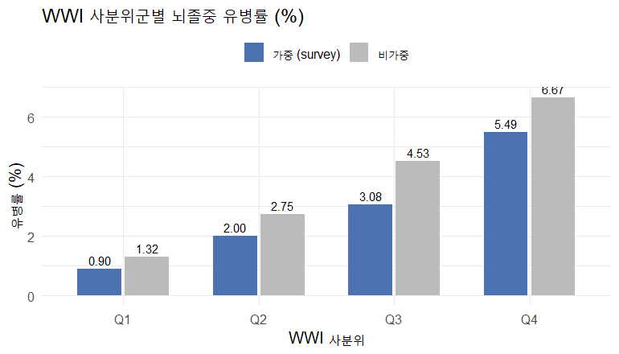

가중치를 반영하면 Q4의 뇌졸중 유병률이 6.67% → 5.49%로 내려갑니다(논문 5.49%와 일치). NHANES가 고령자를 과대표집했기 때문입니다. 논문 Table 1의 5.49%는 가중치 쪽에 가깝습니다.

재현이 드러낸 논문의 불일치

Methods에는 "proper NHANES sample weights"를 썼다고 되어 있지만, Table 2의 OR은 **비가중 `glm()` 결과와 소수 둘째 자리까지 일치**하고 가중 `svyglm()` 결과(2.18)와는 다릅니다. Table 1은 가중, Table 2·3은 비가중으로 계산된 것으로 보입니다. 이런 혼용은 NHANES 논문에서 드물지 않은 오류이며, "인공지능이 가중치를 반영하는지 확인하라"는 검증 과제는 정확히 이런 차이를 잡아내라는 뜻입니다. 재현할 때 **어느 표를 맞추려는지**에 따라 `glm`과 `svyglm` 중 골라야 합니다.

### 9-2. 제외 단계별 인원을 논문과 대조한다

③의 표 참조 — 4단계 모두 정확히 일치(45,462 → 42,486 → 37,719 → 23,389). 추가로 뇌졸중 893명, 남 11,409 / 여 11,980, 나이 49.32 ± 17.42, WWI 11.09 ± 0.86, 절단점 10.51/11.09/11.67 모두 일치. 4분위군 인원도 절단 구간을 [a, b)로 두면(`cut(right = FALSE)`) 5,847/5,847/5,847/5,848로 일치합니다 — 절단점과 정확히 같은 WWI를 가진 사람이 각 1명 있어 동점 처리 방향이 n을 바꿉니다.

### 9-3. Q–Q plot 이론분위수 산출식을 내장함수와 대조한다

PDF §2.3의 식 \(p_i = \dfrac{i-a}{n+1-2a}\) (\(a=3/8\) if \(n\le 10\), else \(1/2\))을 손으로 계산해 R의 `ppoints()`와 `qqnorm()$x`에 대조했습니다.

| n = 5 | i=1 | i=2 | i=3 | i=4 | i=5 |
| --- | --- | --- | --- | --- | --- |
| 손계산 \(p_i\) | 0.1190 | 0.3095 | 0.5000 | 0.6905 | 0.8810 |
| `ppoints(5)` | 0.1190 | 0.3095 | 0.5000 | 0.6905 | 0.8810 |
| 손계산 \(\Phi^{-1}(p_i)\) | −1.180 | −0.497 | 0.000 | 0.497 | 1.180 |
| `qqnorm(x)$x` (정렬) | −1.180 | −0.497 | 0.000 | 0.497 | 1.180 |

✔ n = 5 (a = 3/8)와 n = 20 (a = 1/2) 모두 완전 일치. `stopifnot(all.equal(...))`로 자동 검증됨 (`R/03_figures.R`).

### 9-4. Table 1 재현 요약 (가중, 일부)

발표용 재현 과정 기록(최초 vs 최종 대조표, 시도별 타임라인, 결정적 프롬프트, 되돌리기 검증): **재현_로그_발표용.html**

11단계 실험의 전체 기록과 논문의 방법론적 실수 10가지는 별도 문서 **재현_실험_기록과_논문의_허점.html**에 정리했습니다.

전체 셀을 논문과 같은 배치로 나란히 놓고 차이를 색으로 표시한 표: **Table1_비교.html** (일치 132 · 근소 7 · 차이 13, 차이는 모두 의도된 것).

| 항목 | Q1 재현 | Q1 논문 | Q4 재현 | Q4 논문 |
| --- | --- | --- | --- | --- |
| 나이 | 37.06 ± 13.45 | 37.06 ± 13.45 | 57.47 ± 16.15 | 57.47 ± 16.14 |
| 남성 % | 59.02 | 59.02 | 32.29 | 32.29 |
| BMI | 24.96 ± 4.70 | 24.96 ± 4.70 | 34.23 ± 7.83 | 34.22 ± 7.82 |
| 허리둘레 | 86.09 ± 10.56 | 86.09 ± 10.56 | 115.34 ± 16.13 | 115.34 ± 16.13 |
| 고혈압 % | 13.89 | 13.89 | 52.81 | 52.73 |
| 뇌졸중 % | 0.90 | 0.90 | 5.49 | 5.49 |
| 당뇨 % (경계성 포함) | 3.01 | 3.01 | 26.78 | 26.76 |

불일치 원인을 찾은 방법 — 가설 검정의 반복 (`R/06_diagnose_discrepancies.R`)

한 번에 하나의 규칙만 바꾸고, 각 가설의 점수 = Σ|재현 − 논문|(4개 사분위의 평균과 SD)를 계산해 가장 작은 것을 채택했습니다.

| 검정 | 가설 후보 | 결과 | 결론 |
| --- | --- | --- | --- |
| A·I. 가중치 | MEC CDC 재조정 / MEC 원가중치 / 균등 / 설문 CDC 재조정 / **설문 원가중치** / 비가중 + P주기 계수 연속 스캔 | 점수 16.8 → 9.8(MEC 원) → **1.0(설문 원)**; 음주량 행 소수 둘째 자리까지 일치 | 논문은 **설문 가중치를 재조정 없이** 사용 |
| B. 중성지방·LDL | 대치 없음 / 전체 평균 / 사분위별 평균 / 중앙값 / 회귀 예측 / 비가중 | LDL 점수 53.2 → 1.3, 예상 SD 22.4 vs 논문 22.37 | 결측 54%를 **전체 평균으로 대치** |
| C. 교육 | 3가지 재코딩 × 2가지 가중치 | 재코딩은 현재 규칙이 최적, 가중치 A로 6.3 → 2.4 | 코딩 문제 아님, 가중치 문제 |
| E·F. SD 공식·P값 | 가중 SD 공식 4종 / P: 설계기반 F, LRT, 단순 가중회귀 lm(weights), 비가중 | SD 공식은 무관; 음주량 P는 단순 가중회귀만 0.187 일치(설계기반 0.496) | 논문 P = **층·군집 무시한 가중회귀** |
| D. PIR·HDL·TC·음주 | 대치 없음 / 전체 평균 대치 | PIR 0.36 → 0.03, HDL 1.56 → 0.28, TC 4.16 → 0.58, 음주 2.95 → 16.5(악화) | 세 변수는 평균 대치, **음주는 대치 안 함** |

평균 대치는 SD를 √(관측비율)배로 줄이고 사분위별 평균을 전체 평균 쪽으로 끌어당깁니다. 통계적으로 권장되지 않는 방법이지만(변동을 과소평가), 논문이 실제로 무엇을 했는지 역산하는 데는 이 "지문"이 결정적이었습니다.

## ⑩ 부록 — 실행 방법과 파일 목록

| 파일 | 역할 |
| --- | --- |
| `R/01_download_nhanes.R` | nhanesA로 4개 주기 × 10개 표 = 40개 파일 다운로드 → `data/raw/*.rds`, 주기별 인원 합계 검증 |
| `R/02_preprocess.R` | 표 결합, Fig.1 제외 단계 대조, WWI·4분위, 가중치 재조정, 분포 진단(왜도·S–W·Levene), 가중 vs 비가중 비교, Model 1 → `data/analysis_wwi_stroke.rds/csv` |
| `R/03_figures.R` | 히스토그램·Q–Q·상자그림(원/로그), 유병률 막대, ppoints 검증 → `figures/*.png` |
| `R/04_table1.R` | 가중 Table 1 재현 → `data/table1_reproduced.csv` |
| `R/05_compare_table1.R` + `R/05b_build_compare_html.py` | 논문 Table 1 vs 재현값 셀 단위 비교 → `data/table1_comparison.csv` → `Table1_비교.html` |
| `R/06_diagnose_discrepancies.R` | 불일치 원인 가설 검정 (가중치 방식 A, 결측 대치 B·D, 교육 재코딩 C) — 점수 = Σ\|재현 − 논문\| |

```
# VS Code 터미널(PowerShell)에서, 과제 폴더로 이동한 뒤 순서대로:
& "C:\Program Files\R\R-4.6.1\bin\Rscript.exe" R\01_download_nhanes.R
& "C:\Program Files\R\R-4.6.1\bin\Rscript.exe" R\02_preprocess.R
& "C:\Program Files\R\R-4.6.1\bin\Rscript.exe" R\03_figures.R
& "C:\Program Files\R\R-4.6.1\bin\Rscript.exe" R\04_table1.R
& "C:\Program Files\R\R-4.6.1\bin\Rscript.exe" R\05_compare_table1.R
uv run R\05b_build_compare_html.py
& "C:\Program Files\R\R-4.6.1\bin\Rscript.exe" R\06_diagnose_discrepancies.R
```

R 4.6.1이 `C:\Program Files\R\R-4.6.1`에, 패키지(nhanesA, survey, ggplot2, dplyr, car, moments 등)는 `%LOCALAPPDATA%\R\win-library\4.6`에 설치되어 있습니다. VS Code R 확장이 R을 못 찾으면 설정 `r.rpath.windows`에 `C:\Program Files\R\R-4.6.1\bin\R.exe`를 지정하세요.

### 이 문서에서 다루지 않은 것 (PDF 참조)

| 주제 | PDF 절 |
| --- | --- |
| 평균·SD·왜도·첨도 수식과 예제 | §2.2 |
| Q–Q plot 이론분위수 유도, \(\Phi^{-1}\) | §2.3 |
| Shapiro–Wilk W 통계량, 큰 표본에서의 함정 | §2.4 |
| Levene 검정 = \|편차\|에 대한 ANOVA | §2.5 |
| 로그정규분포, 기하평균, 젠센 부등식 | §2.6 |
| 가중평균(Hájek), 설계효과, svymean/svyglm | §2.7 |
| 경향성 검정 | §4.3 |
| 카이제곱, Rao–Scott 보정 | §5.2, §5.6 |
| 오즈비 vs 상대위험 | §5.3 |
| 로지스틱 회귀, 로짓, 최대우도, LRT | §7.1–7.2 |
| 스플라인(범주화의 대안) | §10.6 |
| 교란의 정의, E-value | §11.1, §11.5 |